# (Ford GoBike System Data)

## Preliminary Wrangling

> This data set includes information about individual rides made in a bike-sharing system covering the greater San Francisco Bay area.

```python
# import all packages and set plots to be embedded inline
import numpy as np
import pandas as pd
import matplotlib.pyplot as plt
import seaborn as sb

%matplotlib inline
```

> Loading the dataset

```python
df_8_1=pd.read_csv('201801-fordgobike-tripdata.csv')
df_8_2=pd.read_csv('201802-fordgobike-tripdata.csv')
df_8_3=pd.read_csv('201803-fordgobike-tripdata.csv')
df_8_4=pd.read_csv('201804-fordgobike-tripdata.csv')
df_8_5=pd.read_csv('201805-fordgobike-tripdata.csv')
df_8_6=pd.read_csv('201806-fordgobike-tripdata.csv')
df_8_7=pd.read_csv('201807-fordgobike-tripdata.csv')
df_8_8=pd.read_csv('201808-fordgobike-tripdata.csv')
df_8_9=pd.read_csv('201809-fordgobike-tripdata.csv')
df_8_10=pd.read_csv('201810-fordgobike-tripdata.csv')
df_8_11=pd.read_csv('201811-fordgobike-tripdata.csv')
df_8_12=pd.read_csv('201812-fordgobike-tripdata.csv')

#frames = []

#import glob
#for file_name in glob.glob("*.csv"):
    #frame = pd.read_csv(file_name, index_col=None, header=0)
    #frames.append(frame)

frames = [df_8_1,df_8_2,df_8_3,df_8_4,df_8_5,df_8_6,df_8_7,df_8_8,df_8_9,df_8_10,df_8_11,df_8_12]
df = pd.concat(frames)
```

```python
df.sort_values(by='start_time')
```

|  | duration_sec | start_time | end_time | start_station_id | start_station_name | start_station_latitude | start_station_longitude | end_station_id | end_station_name | end_station_latitude | end_station_longitude | bike_id | user_type | member_birth_year | member_gender | bike_share_for_all_trip |
| --- | --- | --- | --- | --- | --- | --- | --- | --- | --- | --- | --- | --- | --- | --- | --- | --- |
| 94662 | 13709 | 2018-01-01 00:01:53.8470 | 2018-01-01 03:50:23.4330 | 86.0 | Market St at Dolores St | 37.769305 | -122.426826 | 119.0 | 18th St at Noe St | 37.761047 | -122.432642 | 2924 | Customer | NaN | NaN | No |
| 94801 | 145 | 2018-01-01 00:07:41.0400 | 2018-01-01 00:10:06.2410 | 316.0 | San Salvador St at 1st St | 37.330165 | -121.885831 | 311.0 | Paseo De San Antonio at 2nd St | 37.333798 | -121.886943 | 2473 | Subscriber | 1957.0 | Male | No |
| 94800 | 714 | 2018-01-01 00:07:52.9430 | 2018-01-01 00:19:47.0750 | 74.0 | Laguna St at Hayes St | 37.776435 | -122.426244 | 70.0 | Central Ave at Fell St | 37.773311 | -122.444293 | 2423 | Subscriber | 1986.0 | Male | No |
| 94799 | 1151 | 2018-01-01 00:09:31.7450 | 2018-01-01 00:28:43.1590 | 97.0 | 14th St at Mission St | 37.768265 | -122.420110 | 125.0 | 20th St at Bryant St | 37.759200 | -122.409851 | 3455 | Subscriber | 1992.0 | Male | No |
| 94793 | 1359 | 2018-01-01 00:14:37.1870 | 2018-01-01 00:37:16.4450 | 11.0 | Davis St at Jackson St | 37.797280 | -122.398436 | 323.0 | Broadway at Kearny | 37.798014 | -122.405950 | 2173 | Customer | 1995.0 | Male | No |
| 94658 | 17554 | 2018-01-01 00:15:26.6390 | 2018-01-01 05:08:01.0050 | 55.0 | Webster St at Grove St | 37.777053 | -122.429558 | 285.0 | Webster St at O'Farrell St | 37.783521 | -122.431158 | 2315 | Customer | NaN | NaN | No |
| 94791 | 1451 | 2018-01-01 00:15:30.5200 | 2018-01-01 00:39:42.4910 | 55.0 | Webster St at Grove St | 37.777053 | -122.429558 | 29.0 | O'Farrell St at Divisadero St | 37.782405 | -122.439446 | 1128 | Customer | NaN | NaN | No |
| 94770 | 2603 | 2018-01-01 00:15:33.3690 | 2018-01-01 00:58:56.5220 | 17.0 | Embarcadero BART Station (Beale St at Market St) | 37.792251 | -122.397086 | 8.0 | The Embarcadero at Vallejo St | 37.799953 | -122.398525 | 1788 | Subscriber | 1994.0 | Male | Yes |
| 94766 | 2478 | 2018-01-01 00:17:54.5880 | 2018-01-01 00:59:13.4480 | 17.0 | Embarcadero BART Station (Beale St at Market St) | 37.792251 | -122.397086 | 8.0 | The Embarcadero at Vallejo St | 37.799953 | -122.398525 | 1586 | Subscriber | 1993.0 | Female | Yes |
| 94796 | 752 | 2018-01-01 00:19:13.7100 | 2018-01-01 00:31:46.3440 | 23.0 | The Embarcadero at Steuart St | 37.791464 | -122.391034 | 66.0 | 3rd St at Townsend St | 37.778742 | -122.392741 | 1019 | Customer | NaN | NaN | No |
| 94780 | 1942 | 2018-01-01 00:19:19.6540 | 2018-01-01 00:51:42.1200 | 23.0 | The Embarcadero at Steuart St | 37.791464 | -122.391034 | 19.0 | Post St at Kearny St | 37.788975 | -122.403452 | 1112 | Customer | NaN | NaN | No |
| 94782 | 1928 | 2018-01-01 00:19:21.5860 | 2018-01-01 00:51:29.6840 | 23.0 | The Embarcadero at Steuart St | 37.791464 | -122.391034 | 19.0 | Post St at Kearny St | 37.788975 | -122.403452 | 2522 | Customer | NaN | NaN | No |
| 94781 | 1928 | 2018-01-01 00:19:33.3150 | 2018-01-01 00:51:41.3280 | 23.0 | The Embarcadero at Steuart St | 37.791464 | -122.391034 | 19.0 | Post St at Kearny St | 37.788975 | -122.403452 | 3496 | Customer | NaN | NaN | No |
| 94798 | 600 | 2018-01-01 00:19:48.7610 | 2018-01-01 00:29:49.0740 | 17.0 | Embarcadero BART Station (Beale St at Market St) | 37.792251 | -122.397086 | 19.0 | Post St at Kearny St | 37.788975 | -122.403452 | 603 | Customer | NaN | NaN | No |
| 94764 | 2379 | 2018-01-01 00:19:49.1170 | 2018-01-01 00:59:28.2030 | 17.0 | Embarcadero BART Station (Beale St at Market St) | 37.792251 | -122.397086 | 8.0 | The Embarcadero at Vallejo St | 37.799953 | -122.398525 | 346 | Subscriber | 1994.0 | Female | Yes |
| 94797 | 695 | 2018-01-01 00:19:58.7610 | 2018-01-01 00:31:33.8320 | 23.0 | The Embarcadero at Steuart St | 37.791464 | -122.391034 | 66.0 | 3rd St at Townsend St | 37.778742 | -122.392741 | 3671 | Customer | NaN | NaN | No |
| 94763 | 2385 | 2018-01-01 00:20:05.9700 | 2018-01-01 00:59:51.1870 | 15.0 | San Francisco Ferry Building (Harry Bridges Pl... | 37.795392 | -122.394203 | 17.0 | Embarcadero BART Station (Beale St at Market St) | 37.792251 | -122.397086 | 2537 | Customer | NaN | NaN | No |
| 94783 | 1866 | 2018-01-01 00:20:21.6800 | 2018-01-01 00:51:28.0690 | 23.0 | The Embarcadero at Steuart St | 37.791464 | -122.391034 | 19.0 | Post St at Kearny St | 37.788975 | -122.403452 | 2721 | Customer | NaN | NaN | No |
| 94773 | 2284 | 2018-01-01 00:20:29.7820 | 2018-01-01 00:58:34.0220 | 15.0 | San Francisco Ferry Building (Harry Bridges Pl... | 37.795392 | -122.394203 | 17.0 | Embarcadero BART Station (Beale St at Market St) | 37.792251 | -122.397086 | 2941 | Customer | NaN | NaN | No |
| 94792 | 1099 | 2018-01-01 00:20:47.3600 | 2018-01-01 00:39:07.1620 | 16.0 | Steuart St at Market St | 37.794130 | -122.394430 | 93.0 | 4th St at Mission Bay Blvd S | 37.770407 | -122.391198 | 2670 | Customer | 1984.0 | Female | No |
| 94756 | 2934 | 2018-01-01 00:21:13.9580 | 2018-01-01 01:10:08.6060 | 15.0 | San Francisco Ferry Building (Harry Bridges Pl... | 37.795392 | -122.394203 | 17.0 | Embarcadero BART Station (Beale St at Market St) | 37.792251 | -122.397086 | 1648 | Customer | NaN | NaN | No |
| 94790 | 1178 | 2018-01-01 00:21:23.4470 | 2018-01-01 00:41:01.4580 | 8.0 | The Embarcadero at Vallejo St | 37.799953 | -122.398525 | 17.0 | Embarcadero BART Station (Beale St at Market St) | 37.792251 | -122.397086 | 1031 | Customer | NaN | NaN | No |
| 94761 | 2656 | 2018-01-01 00:21:29.7020 | 2018-01-01 01:05:46.1670 | 8.0 | The Embarcadero at Vallejo St | 37.799953 | -122.398525 | 17.0 | Embarcadero BART Station (Beale St at Market St) | 37.792251 | -122.397086 | 1938 | Customer | NaN | NaN | No |
| 94788 | 1177 | 2018-01-01 00:21:31.4350 | 2018-01-01 00:41:08.4570 | 8.0 | The Embarcadero at Vallejo St | 37.799953 | -122.398525 | 17.0 | Embarcadero BART Station (Beale St at Market St) | 37.792251 | -122.397086 | 283 | Customer | NaN | NaN | No |
| 94794 | 638 | 2018-01-01 00:23:01.9500 | 2018-01-01 00:33:40.4940 | 15.0 | San Francisco Ferry Building (Harry Bridges Pl... | 37.795392 | -122.394203 | 22.0 | Howard St at Beale St | 37.789756 | -122.394643 | 1746 | Customer | NaN | NaN | No |
| 94795 | 627 | 2018-01-01 00:23:04.3280 | 2018-01-01 00:33:32.3080 | 15.0 | San Francisco Ferry Building (Harry Bridges Pl... | 37.795392 | -122.394203 | 22.0 | Howard St at Beale St | 37.789756 | -122.394643 | 2454 | Customer | NaN | NaN | No |
| 94779 | 1699 | 2018-01-01 00:23:25.8890 | 2018-01-01 00:51:45.8490 | 23.0 | The Embarcadero at Steuart St | 37.791464 | -122.391034 | 19.0 | Post St at Kearny St | 37.788975 | -122.403452 | 3375 | Customer | NaN | NaN | No |
| 94789 | 1043 | 2018-01-01 00:23:39.1320 | 2018-01-01 00:41:02.4170 | 8.0 | The Embarcadero at Vallejo St | 37.799953 | -122.398525 | 17.0 | Embarcadero BART Station (Beale St at Market St) | 37.792251 | -122.397086 | 1979 | Customer | NaN | NaN | No |
| 94713 | 5765 | 2018-01-01 00:24:19.5140 | 2018-01-01 02:00:25.1100 | 304.0 | Jackson St at 5th St | 37.348759 | -121.894798 | 305.0 | Ryland Park | 37.342725 | -121.895617 | 1747 | Customer | NaN | NaN | No |
| 94714 | 5566 | 2018-01-01 00:26:57.6620 | 2018-01-01 01:59:43.7330 | 304.0 | Jackson St at 5th St | 37.348759 | -121.894798 | 305.0 | Ryland Park | 37.342725 | -121.895617 | 2533 | Customer | NaN | NaN | No |
| ... | ... | ... | ... | ... | ... | ... | ... | ... | ... | ... | ... | ... | ... | ... | ... | ... |
| 41 | 244 | 2018-12-31 23:31:48.8310 | 2018-12-31 23:35:53.8000 | 78.0 | Folsom St at 9th St | 37.773717 | -122.411647 | 321.0 | 5th St at Folsom | 37.780146 | -122.403071 | 1976 | Subscriber | 1990.0 | Female | No |
| 30 | 1024 | 2018-12-31 23:32:11.7910 | 2018-12-31 23:49:16.0290 | 114.0 | Rhode Island St at 17th St | 37.764478 | -122.402570 | 24.0 | Spear St at Folsom St | 37.789677 | -122.390428 | 4714 | Subscriber | 1986.0 | Female | No |
| 28 | 1005 | 2018-12-31 23:32:40.1770 | 2018-12-31 23:49:25.5310 | 114.0 | Rhode Island St at 17th St | 37.764478 | -122.402570 | 24.0 | Spear St at Folsom St | 37.789677 | -122.390428 | 5288 | Subscriber | 1985.0 | Male | No |
| 42 | 117 | 2018-12-31 23:33:08.1410 | 2018-12-31 23:35:06.0750 | 81.0 | Berry St at 4th St | 37.775880 | -122.393170 | 91.0 | Berry St at King St | 37.771762 | -122.398438 | 3706 | Subscriber | 1980.0 | Male | No |
| 27 | 844 | 2018-12-31 23:35:37.0050 | 2018-12-31 23:49:41.6010 | 23.0 | The Embarcadero at Steuart St | 37.791464 | -122.391034 | 23.0 | The Embarcadero at Steuart St | 37.791464 | -122.391034 | 5112 | Subscriber | 1991.0 | Male | No |
| 39 | 131 | 2018-12-31 23:36:42.7280 | 2018-12-31 23:38:54.6280 | 76.0 | McCoppin St at Valencia St | 37.771662 | -122.422423 | 98.0 | Valencia St at 16th St | 37.765052 | -122.421866 | 4908 | Subscriber | 1987.0 | Male | No |
| 33 | 373 | 2018-12-31 23:38:28.1620 | 2018-12-31 23:44:41.3180 | 97.0 | 14th St at Mission St | 37.768265 | -122.420110 | 120.0 | Mission Dolores Park | 37.761420 | -122.426435 | 422 | Subscriber | 1993.0 | Male | No |
| 26 | 828 | 2018-12-31 23:39:39.6750 | 2018-12-31 23:53:27.7270 | 4.0 | Cyril Magnin St at Ellis St | 37.785881 | -122.408915 | 123.0 | Folsom St at 19th St | 37.760594 | -122.414817 | 4780 | Subscriber | 1971.0 | Male | No |
| 35 | 158 | 2018-12-31 23:40:16.2300 | 2018-12-31 23:42:55.2270 | 3.0 | Powell St BART Station (Market St at 4th St) | 37.786375 | -122.404904 | 44.0 | Civic Center/UN Plaza BART Station (Market St ... | 37.781074 | -122.411738 | 5313 | Subscriber | 1984.0 | Male | No |
| 36 | 153 | 2018-12-31 23:40:20.0660 | 2018-12-31 23:42:53.7160 | 5.0 | Powell St BART Station (Market St at 5th St) | 37.783899 | -122.408445 | 349.0 | Howard St at Mary St | 37.781010 | -122.405666 | 5537 | Subscriber | 1973.0 | Male | Yes |
| 25 | 704 | 2018-12-31 23:41:48.9780 | 2018-12-31 23:53:33.8790 | 64.0 | 5th St at Brannan St | 37.776754 | -122.399018 | 23.0 | The Embarcadero at Steuart St | 37.791464 | -122.391034 | 4983 | Subscriber | 1986.0 | Male | Yes |
| 31 | 149 | 2018-12-31 23:45:16.7860 | 2018-12-31 23:47:46.6760 | 98.0 | Valencia St at 16th St | 37.765052 | -122.421866 | 76.0 | McCoppin St at Valencia St | 37.771662 | -122.422423 | 4908 | Subscriber | 1987.0 | Male | No |
| 24 | 471 | 2018-12-31 23:45:54.6470 | 2018-12-31 23:53:46.2510 | 5.0 | Powell St BART Station (Market St at 5th St) | 37.783899 | -122.408445 | 324.0 | Union Square (Powell St at Post St) | 37.788300 | -122.408531 | 4810 | Subscriber | 1985.0 | Male | No |
| 19 | 584 | 2018-12-31 23:46:18.3240 | 2018-12-31 23:56:02.3290 | 62.0 | Victoria Manalo Draves Park | 37.777791 | -122.406432 | 95.0 | Sanchez St at 15th St | 37.766219 | -122.431060 | 5502 | Subscriber | 1994.0 | Male | No |
| 6 | 2502 | 2018-12-31 23:46:24.9430 | 2019-01-01 00:28:07.3560 | 67.0 | San Francisco Caltrain Station 2 (Townsend St... | 37.776639 | -122.395526 | 44.0 | Civic Center/UN Plaza BART Station (Market St ... | 37.781074 | -122.411738 | 4706 | Customer | 1973.0 | Male | No |
| 14 | 868 | 2018-12-31 23:46:34.4110 | 2019-01-01 00:01:02.7040 | 350.0 | 8th St at Brannan St | 37.771431 | -122.405787 | 23.0 | The Embarcadero at Steuart St | 37.791464 | -122.391034 | 4615 | Subscriber | 1984.0 | Male | No |
| 23 | 460 | 2018-12-31 23:46:37.7380 | 2018-12-31 23:54:18.5470 | 323.0 | Broadway at Kearny | 37.798014 | -122.405950 | 19.0 | Post St at Kearny St | 37.788975 | -122.403452 | 1843 | Subscriber | 1989.0 | Male | Yes |
| 10 | 2182 | 2018-12-31 23:47:02.1850 | 2019-01-01 00:23:24.4950 | 6.0 | The Embarcadero at Sansome St | 37.804770 | -122.403234 | 21.0 | Montgomery St BART Station (Market St at 2nd St) | 37.789625 | -122.400811 | 5426 | Customer | 1999.0 | Female | No |
| 16 | 816 | 2018-12-31 23:47:16.8790 | 2019-01-01 00:00:53.7470 | 350.0 | 8th St at Brannan St | 37.771431 | -122.405787 | 23.0 | The Embarcadero at Steuart St | 37.791464 | -122.391034 | 5357 | Customer | 1982.0 | Male | No |
| 8 | 2170 | 2018-12-31 23:47:19.2100 | 2019-01-01 00:23:30.1300 | 6.0 | The Embarcadero at Sansome St | 37.804770 | -122.403234 | 21.0 | Montgomery St BART Station (Market St at 2nd St) | 37.789625 | -122.400811 | 4800 | Customer | 1999.0 | Female | No |
| 15 | 814 | 2018-12-31 23:47:20.2940 | 2019-01-01 00:00:54.9200 | 350.0 | 8th St at Brannan St | 37.771431 | -122.405787 | 23.0 | The Embarcadero at Steuart St | 37.791464 | -122.391034 | 4811 | Subscriber | 1988.0 | Female | No |
| 17 | 535 | 2018-12-31 23:48:31.3300 | 2018-12-31 23:57:27.1690 | 37.0 | 2nd St at Folsom St | 37.785000 | -122.395936 | 16.0 | Steuart St at Market St | 37.794130 | -122.394430 | 2677 | Subscriber | 1975.0 | Male | Yes |
| 18 | 482 | 2018-12-31 23:48:38.1980 | 2018-12-31 23:56:40.8020 | 341.0 | Fountain Alley at S 2nd St | 37.336188 | -121.889277 | 296.0 | 5th St at Virginia St | 37.325998 | -121.877120 | 3853 | Subscriber | 1995.0 | Male | Yes |
| 21 | 411 | 2018-12-31 23:48:49.4140 | 2018-12-31 23:55:40.6540 | 21.0 | Montgomery St BART Station (Market St at 2nd St) | 37.789625 | -122.400811 | 16.0 | Steuart St at Market St | 37.794130 | -122.394430 | 5247 | Subscriber | 1996.0 | Male | Yes |
| 22 | 397 | 2018-12-31 23:48:55.6080 | 2018-12-31 23:55:33.5600 | 21.0 | Montgomery St BART Station (Market St at 2nd St) | 37.789625 | -122.400811 | 16.0 | Steuart St at Market St | 37.794130 | -122.394430 | 4962 | Subscriber | 1996.0 | Male | Yes |
| 20 | 386 | 2018-12-31 23:49:14.0480 | 2018-12-31 23:55:40.9170 | 21.0 | Montgomery St BART Station (Market St at 2nd St) | 37.789625 | -122.400811 | 16.0 | Steuart St at Market St | 37.794130 | -122.394430 | 5463 | Subscriber | 1994.0 | Male | Yes |
| 12 | 972 | 2018-12-31 23:52:27.2600 | 2019-01-01 00:08:39.3990 | 238.0 | MLK Jr Way at University Ave | 37.871719 | -122.273068 | 238.0 | MLK Jr Way at University Ave | 37.871719 | -122.273068 | 1047 | Subscriber | 1985.0 | Male | Yes |
| 13 | 683 | 2018-12-31 23:52:33.0890 | 2019-01-01 00:03:57.0540 | 247.0 | Fulton St at Bancroft Way | 37.867789 | -122.265896 | 245.0 | Downtown Berkeley BART | 37.870139 | -122.268422 | 3502 | Customer | 2000.0 | Male | No |
| 5 | 2149 | 2018-12-31 23:59:11.8820 | 2019-01-01 00:35:01.6850 | 3.0 | Powell St BART Station (Market St at 4th St) | 37.786375 | -122.404904 | 368.0 | Myrtle St at Polk St | 37.785434 | -122.419622 | 5549 | Subscriber | 1982.0 | Male | Yes |
| 4 | 2150 | 2018-12-31 23:59:12.0970 | 2019-01-01 00:35:02.1530 | 3.0 | Powell St BART Station (Market St at 4th St) | 37.786375 | -122.404904 | 368.0 | Myrtle St at Polk St | 37.785434 | -122.419622 | 4820 | Customer | NaN | NaN | No |

1863721 rows × 16 columns

```python
df.info(verbose =True,null_counts =True)
##droping the start_station_latitude
#start_station_longitude
#end_station_latitude
#end_station_longitude
# as we would use it in farther analysis
```

```
<class 'pandas.core.frame.DataFrame'>
Int64Index: 1863721 entries, 0 to 131362
Data columns (total 16 columns):
duration_sec               1863721 non-null int64
start_time                 1863721 non-null object
end_time                   1863721 non-null object
start_station_id           1851950 non-null float64
start_station_name         1851950 non-null object
start_station_latitude     1863721 non-null float64
start_station_longitude    1863721 non-null float64
end_station_id             1851950 non-null float64
end_station_name           1851950 non-null object
end_station_latitude       1863721 non-null float64
end_station_longitude      1863721 non-null float64
bike_id                    1863721 non-null int64
user_type                  1863721 non-null object
member_birth_year          1753003 non-null float64
member_gender              1753354 non-null object
bike_share_for_all_trip    1863721 non-null object
dtypes: float64(7), int64(2), object(7)
memory usage: 241.7+ MB
```

```python
df.describe()
```

|  | duration_sec | start_station_id | start_station_latitude | start_station_longitude | end_station_id | end_station_latitude | end_station_longitude | bike_id | member_birth_year |
| --- | --- | --- | --- | --- | --- | --- | --- | --- | --- |
| count | 1.863721e+06 | 1.851950e+06 | 1.863721e+06 | 1.863721e+06 | 1.851950e+06 | 1.863721e+06 | 1.863721e+06 | 1.863721e+06 | 1.753003e+06 |
| mean | 8.573026e+02 | 1.196744e+02 | 3.776678e+01 | -1.223492e+02 | 1.181730e+02 | 3.776690e+01 | -1.223487e+02 | 2.296851e+03 | 1.983088e+03 |
| std | 2.370379e+03 | 1.003976e+02 | 1.057689e-01 | 1.654634e-01 | 1.004403e+02 | 1.056483e-01 | 1.650597e-01 | 1.287733e+03 | 1.044289e+01 |
| min | 6.100000e+01 | 3.000000e+00 | 3.726331e+01 | -1.224737e+02 | 3.000000e+00 | 3.726331e+01 | -1.224737e+02 | 1.100000e+01 | 1.881000e+03 |
| 25% | 3.500000e+02 | 3.300000e+01 | 3.777106e+01 | -1.224114e+02 | 3.000000e+01 | 3.777106e+01 | -1.224094e+02 | 1.225000e+03 | 1.978000e+03 |
| 50% | 5.560000e+02 | 8.900000e+01 | 3.778107e+01 | -1.223974e+02 | 8.800000e+01 | 3.778127e+01 | -1.223971e+02 | 2.338000e+03 | 1.985000e+03 |
| 75% | 8.720000e+02 | 1.860000e+02 | 3.779625e+01 | -1.222865e+02 | 1.830000e+02 | 3.779728e+01 | -1.222894e+02 | 3.333000e+03 | 1.991000e+03 |
| max | 8.636600e+04 | 3.810000e+02 | 4.551000e+01 | -7.357000e+01 | 3.810000e+02 | 4.551000e+01 | -7.357000e+01 | 6.234000e+03 | 2.000000e+03 |

## droping columns which not will be used in our analysis

```python
df.drop(axis=1,inplace=True,columns=['start_station_latitude','start_station_longitude','end_station_latitude',
                                     'end_station_longitude'
                                     ,'bike_id','start_station_id','end_station_id'])

#df['start_station_id'] = df['start_station_id'].astype(str)
#df['end_station_id'] = df['end_station_id'].astype(str)
#def remove_0 (x):
#    return x[:-2]


#df['start_station_id']=df['start_station_id'].apply(remove_0)
#df['end_station_id']=df['end_station_id'].apply(remove_0)
#df[['start_station_id','end_station_id']]
```

## change the scale of time from sec to Min to be more efficent

```python
df['duration_sec']=df['duration_sec']/60
df.rename(columns={'duration_sec':'duration_min'},inplace=True)
df.sort_values(by='start_time')
```

|  | duration_min | start_time | end_time | start_station_name | end_station_name | user_type | member_birth_year | member_gender | bike_share_for_all_trip |
| --- | --- | --- | --- | --- | --- | --- | --- | --- | --- |
| 94662 | 228.483333 | 2018-01-01 00:01:53.8470 | 2018-01-01 03:50:23.4330 | Market St at Dolores St | 18th St at Noe St | Customer | NaN | NaN | No |
| 94801 | 2.416667 | 2018-01-01 00:07:41.0400 | 2018-01-01 00:10:06.2410 | San Salvador St at 1st St | Paseo De San Antonio at 2nd St | Subscriber | 1957.0 | Male | No |
| 94800 | 11.900000 | 2018-01-01 00:07:52.9430 | 2018-01-01 00:19:47.0750 | Laguna St at Hayes St | Central Ave at Fell St | Subscriber | 1986.0 | Male | No |
| 94799 | 19.183333 | 2018-01-01 00:09:31.7450 | 2018-01-01 00:28:43.1590 | 14th St at Mission St | 20th St at Bryant St | Subscriber | 1992.0 | Male | No |
| 94793 | 22.650000 | 2018-01-01 00:14:37.1870 | 2018-01-01 00:37:16.4450 | Davis St at Jackson St | Broadway at Kearny | Customer | 1995.0 | Male | No |
| 94658 | 292.566667 | 2018-01-01 00:15:26.6390 | 2018-01-01 05:08:01.0050 | Webster St at Grove St | Webster St at O'Farrell St | Customer | NaN | NaN | No |
| 94791 | 24.183333 | 2018-01-01 00:15:30.5200 | 2018-01-01 00:39:42.4910 | Webster St at Grove St | O'Farrell St at Divisadero St | Customer | NaN | NaN | No |
| 94770 | 43.383333 | 2018-01-01 00:15:33.3690 | 2018-01-01 00:58:56.5220 | Embarcadero BART Station (Beale St at Market St) | The Embarcadero at Vallejo St | Subscriber | 1994.0 | Male | Yes |
| 94766 | 41.300000 | 2018-01-01 00:17:54.5880 | 2018-01-01 00:59:13.4480 | Embarcadero BART Station (Beale St at Market St) | The Embarcadero at Vallejo St | Subscriber | 1993.0 | Female | Yes |
| 94796 | 12.533333 | 2018-01-01 00:19:13.7100 | 2018-01-01 00:31:46.3440 | The Embarcadero at Steuart St | 3rd St at Townsend St | Customer | NaN | NaN | No |
| 94780 | 32.366667 | 2018-01-01 00:19:19.6540 | 2018-01-01 00:51:42.1200 | The Embarcadero at Steuart St | Post St at Kearny St | Customer | NaN | NaN | No |
| 94782 | 32.133333 | 2018-01-01 00:19:21.5860 | 2018-01-01 00:51:29.6840 | The Embarcadero at Steuart St | Post St at Kearny St | Customer | NaN | NaN | No |
| 94781 | 32.133333 | 2018-01-01 00:19:33.3150 | 2018-01-01 00:51:41.3280 | The Embarcadero at Steuart St | Post St at Kearny St | Customer | NaN | NaN | No |
| 94798 | 10.000000 | 2018-01-01 00:19:48.7610 | 2018-01-01 00:29:49.0740 | Embarcadero BART Station (Beale St at Market St) | Post St at Kearny St | Customer | NaN | NaN | No |
| 94764 | 39.650000 | 2018-01-01 00:19:49.1170 | 2018-01-01 00:59:28.2030 | Embarcadero BART Station (Beale St at Market St) | The Embarcadero at Vallejo St | Subscriber | 1994.0 | Female | Yes |
| 94797 | 11.583333 | 2018-01-01 00:19:58.7610 | 2018-01-01 00:31:33.8320 | The Embarcadero at Steuart St | 3rd St at Townsend St | Customer | NaN | NaN | No |
| 94763 | 39.750000 | 2018-01-01 00:20:05.9700 | 2018-01-01 00:59:51.1870 | San Francisco Ferry Building (Harry Bridges Pl... | Embarcadero BART Station (Beale St at Market St) | Customer | NaN | NaN | No |
| 94783 | 31.100000 | 2018-01-01 00:20:21.6800 | 2018-01-01 00:51:28.0690 | The Embarcadero at Steuart St | Post St at Kearny St | Customer | NaN | NaN | No |
| 94773 | 38.066667 | 2018-01-01 00:20:29.7820 | 2018-01-01 00:58:34.0220 | San Francisco Ferry Building (Harry Bridges Pl... | Embarcadero BART Station (Beale St at Market St) | Customer | NaN | NaN | No |
| 94792 | 18.316667 | 2018-01-01 00:20:47.3600 | 2018-01-01 00:39:07.1620 | Steuart St at Market St | 4th St at Mission Bay Blvd S | Customer | 1984.0 | Female | No |
| 94756 | 48.900000 | 2018-01-01 00:21:13.9580 | 2018-01-01 01:10:08.6060 | San Francisco Ferry Building (Harry Bridges Pl... | Embarcadero BART Station (Beale St at Market St) | Customer | NaN | NaN | No |
| 94790 | 19.633333 | 2018-01-01 00:21:23.4470 | 2018-01-01 00:41:01.4580 | The Embarcadero at Vallejo St | Embarcadero BART Station (Beale St at Market St) | Customer | NaN | NaN | No |
| 94761 | 44.266667 | 2018-01-01 00:21:29.7020 | 2018-01-01 01:05:46.1670 | The Embarcadero at Vallejo St | Embarcadero BART Station (Beale St at Market St) | Customer | NaN | NaN | No |
| 94788 | 19.616667 | 2018-01-01 00:21:31.4350 | 2018-01-01 00:41:08.4570 | The Embarcadero at Vallejo St | Embarcadero BART Station (Beale St at Market St) | Customer | NaN | NaN | No |
| 94794 | 10.633333 | 2018-01-01 00:23:01.9500 | 2018-01-01 00:33:40.4940 | San Francisco Ferry Building (Harry Bridges Pl... | Howard St at Beale St | Customer | NaN | NaN | No |
| 94795 | 10.450000 | 2018-01-01 00:23:04.3280 | 2018-01-01 00:33:32.3080 | San Francisco Ferry Building (Harry Bridges Pl... | Howard St at Beale St | Customer | NaN | NaN | No |
| 94779 | 28.316667 | 2018-01-01 00:23:25.8890 | 2018-01-01 00:51:45.8490 | The Embarcadero at Steuart St | Post St at Kearny St | Customer | NaN | NaN | No |
| 94789 | 17.383333 | 2018-01-01 00:23:39.1320 | 2018-01-01 00:41:02.4170 | The Embarcadero at Vallejo St | Embarcadero BART Station (Beale St at Market St) | Customer | NaN | NaN | No |
| 94713 | 96.083333 | 2018-01-01 00:24:19.5140 | 2018-01-01 02:00:25.1100 | Jackson St at 5th St | Ryland Park | Customer | NaN | NaN | No |
| 94714 | 92.766667 | 2018-01-01 00:26:57.6620 | 2018-01-01 01:59:43.7330 | Jackson St at 5th St | Ryland Park | Customer | NaN | NaN | No |
| ... | ... | ... | ... | ... | ... | ... | ... | ... | ... |
| 41 | 4.066667 | 2018-12-31 23:31:48.8310 | 2018-12-31 23:35:53.8000 | Folsom St at 9th St | 5th St at Folsom | Subscriber | 1990.0 | Female | No |
| 30 | 17.066667 | 2018-12-31 23:32:11.7910 | 2018-12-31 23:49:16.0290 | Rhode Island St at 17th St | Spear St at Folsom St | Subscriber | 1986.0 | Female | No |
| 28 | 16.750000 | 2018-12-31 23:32:40.1770 | 2018-12-31 23:49:25.5310 | Rhode Island St at 17th St | Spear St at Folsom St | Subscriber | 1985.0 | Male | No |
| 42 | 1.950000 | 2018-12-31 23:33:08.1410 | 2018-12-31 23:35:06.0750 | Berry St at 4th St | Berry St at King St | Subscriber | 1980.0 | Male | No |
| 27 | 14.066667 | 2018-12-31 23:35:37.0050 | 2018-12-31 23:49:41.6010 | The Embarcadero at Steuart St | The Embarcadero at Steuart St | Subscriber | 1991.0 | Male | No |
| 39 | 2.183333 | 2018-12-31 23:36:42.7280 | 2018-12-31 23:38:54.6280 | McCoppin St at Valencia St | Valencia St at 16th St | Subscriber | 1987.0 | Male | No |
| 33 | 6.216667 | 2018-12-31 23:38:28.1620 | 2018-12-31 23:44:41.3180 | 14th St at Mission St | Mission Dolores Park | Subscriber | 1993.0 | Male | No |
| 26 | 13.800000 | 2018-12-31 23:39:39.6750 | 2018-12-31 23:53:27.7270 | Cyril Magnin St at Ellis St | Folsom St at 19th St | Subscriber | 1971.0 | Male | No |
| 35 | 2.633333 | 2018-12-31 23:40:16.2300 | 2018-12-31 23:42:55.2270 | Powell St BART Station (Market St at 4th St) | Civic Center/UN Plaza BART Station (Market St ... | Subscriber | 1984.0 | Male | No |
| 36 | 2.550000 | 2018-12-31 23:40:20.0660 | 2018-12-31 23:42:53.7160 | Powell St BART Station (Market St at 5th St) | Howard St at Mary St | Subscriber | 1973.0 | Male | Yes |
| 25 | 11.733333 | 2018-12-31 23:41:48.9780 | 2018-12-31 23:53:33.8790 | 5th St at Brannan St | The Embarcadero at Steuart St | Subscriber | 1986.0 | Male | Yes |
| 31 | 2.483333 | 2018-12-31 23:45:16.7860 | 2018-12-31 23:47:46.6760 | Valencia St at 16th St | McCoppin St at Valencia St | Subscriber | 1987.0 | Male | No |
| 24 | 7.850000 | 2018-12-31 23:45:54.6470 | 2018-12-31 23:53:46.2510 | Powell St BART Station (Market St at 5th St) | Union Square (Powell St at Post St) | Subscriber | 1985.0 | Male | No |
| 19 | 9.733333 | 2018-12-31 23:46:18.3240 | 2018-12-31 23:56:02.3290 | Victoria Manalo Draves Park | Sanchez St at 15th St | Subscriber | 1994.0 | Male | No |
| 6 | 41.700000 | 2018-12-31 23:46:24.9430 | 2019-01-01 00:28:07.3560 | San Francisco Caltrain Station 2 (Townsend St... | Civic Center/UN Plaza BART Station (Market St ... | Customer | 1973.0 | Male | No |
| 14 | 14.466667 | 2018-12-31 23:46:34.4110 | 2019-01-01 00:01:02.7040 | 8th St at Brannan St | The Embarcadero at Steuart St | Subscriber | 1984.0 | Male | No |
| 23 | 7.666667 | 2018-12-31 23:46:37.7380 | 2018-12-31 23:54:18.5470 | Broadway at Kearny | Post St at Kearny St | Subscriber | 1989.0 | Male | Yes |
| 10 | 36.366667 | 2018-12-31 23:47:02.1850 | 2019-01-01 00:23:24.4950 | The Embarcadero at Sansome St | Montgomery St BART Station (Market St at 2nd St) | Customer | 1999.0 | Female | No |
| 16 | 13.600000 | 2018-12-31 23:47:16.8790 | 2019-01-01 00:00:53.7470 | 8th St at Brannan St | The Embarcadero at Steuart St | Customer | 1982.0 | Male | No |
| 8 | 36.166667 | 2018-12-31 23:47:19.2100 | 2019-01-01 00:23:30.1300 | The Embarcadero at Sansome St | Montgomery St BART Station (Market St at 2nd St) | Customer | 1999.0 | Female | No |
| 15 | 13.566667 | 2018-12-31 23:47:20.2940 | 2019-01-01 00:00:54.9200 | 8th St at Brannan St | The Embarcadero at Steuart St | Subscriber | 1988.0 | Female | No |
| 17 | 8.916667 | 2018-12-31 23:48:31.3300 | 2018-12-31 23:57:27.1690 | 2nd St at Folsom St | Steuart St at Market St | Subscriber | 1975.0 | Male | Yes |
| 18 | 8.033333 | 2018-12-31 23:48:38.1980 | 2018-12-31 23:56:40.8020 | Fountain Alley at S 2nd St | 5th St at Virginia St | Subscriber | 1995.0 | Male | Yes |
| 21 | 6.850000 | 2018-12-31 23:48:49.4140 | 2018-12-31 23:55:40.6540 | Montgomery St BART Station (Market St at 2nd St) | Steuart St at Market St | Subscriber | 1996.0 | Male | Yes |
| 22 | 6.616667 | 2018-12-31 23:48:55.6080 | 2018-12-31 23:55:33.5600 | Montgomery St BART Station (Market St at 2nd St) | Steuart St at Market St | Subscriber | 1996.0 | Male | Yes |
| 20 | 6.433333 | 2018-12-31 23:49:14.0480 | 2018-12-31 23:55:40.9170 | Montgomery St BART Station (Market St at 2nd St) | Steuart St at Market St | Subscriber | 1994.0 | Male | Yes |
| 12 | 16.200000 | 2018-12-31 23:52:27.2600 | 2019-01-01 00:08:39.3990 | MLK Jr Way at University Ave | MLK Jr Way at University Ave | Subscriber | 1985.0 | Male | Yes |
| 13 | 11.383333 | 2018-12-31 23:52:33.0890 | 2019-01-01 00:03:57.0540 | Fulton St at Bancroft Way | Downtown Berkeley BART | Customer | 2000.0 | Male | No |
| 5 | 35.816667 | 2018-12-31 23:59:11.8820 | 2019-01-01 00:35:01.6850 | Powell St BART Station (Market St at 4th St) | Myrtle St at Polk St | Subscriber | 1982.0 | Male | Yes |
| 4 | 35.833333 | 2018-12-31 23:59:12.0970 | 2019-01-01 00:35:02.1530 | Powell St BART Station (Market St at 4th St) | Myrtle St at Polk St | Customer | NaN | NaN | No |

1863721 rows × 9 columns

## people older than 85 will be consedr outliers and will be Droped

```python
df.member_birth_year.min()
df[df['member_birth_year'] < 1935].member_birth_year.value_counts() ## people older than 85 will be consedr outliers
```

```
1900.0    632
1911.0    262
1931.0    228
1933.0    226
1902.0    169
1924.0    134
1920.0     91
1934.0     74
1901.0     29
1932.0     25
1888.0     23
1928.0     20
1914.0     18
1904.0     12
1927.0      8
1881.0      5
1909.0      4
1889.0      3
1906.0      2
1903.0      1
1930.0      1
Name: member_birth_year, dtype: int64
```

```python
indexs=df[df['member_birth_year'] < 1935].index
df.drop(axis=0,index=indexs,inplace=True)
df.reset_index(inplace=True)
df.drop('index',axis=1,inplace=True)
```

```python
df[df['duration_min'] > 1000]
# my explenation for this phonomena that they might forget to return the bike so they returned the next day
```

|  | duration_min | start_time | end_time | start_station_name | end_station_name | user_type | member_birth_year | member_gender | bike_share_for_all_trip |
| --- | --- | --- | --- | --- | --- | --- | --- | --- | --- |
| 0 | 1254.733333 | 2018-01-31 22:52:35.2390 | 2018-02-01 19:47:19.8240 | Mission Dolores Park | Webster St at O'Farrell St | Subscriber | 1986.0 | Male | No |
| 1 | 1423.700000 | 2018-01-31 16:13:34.3510 | 2018-02-01 15:57:17.3100 | San Francisco Ferry Building (Harry Bridges Pl... | San Francisco Ferry Building (Harry Bridges Pl... | Customer | NaN | NaN | No |
| 2 | 1192.933333 | 2018-01-31 14:23:55.8890 | 2018-02-01 10:16:52.1160 | Jackson St at 5th St | 5th St at Virginia St | Customer | 1996.0 | Male | No |
| 3 | 1017.933333 | 2018-01-31 14:53:23.5620 | 2018-02-01 07:51:20.5000 | Market St at Franklin St | 4th St at Harrison St | Customer | NaN | NaN | No |
| 1811 | 1199.916667 | 2018-01-30 20:40:36.3990 | 2018-01-31 16:40:31.8070 | Embarcadero BART Station (Beale St at Market St) | San Francisco Caltrain (Townsend St at 4th St) | Customer | NaN | NaN | No |
| 2200 | 1425.766667 | 2018-01-30 14:45:44.4800 | 2018-01-31 14:31:31.0530 | The Embarcadero at Sansome St | Spear St at Folsom St | Customer | NaN | NaN | No |
| 3003 | 1029.033333 | 2018-01-30 16:47:11.8060 | 2018-01-31 09:56:14.6390 | Sanchez St at 15th St | Sanchez St at 17th St | Customer | NaN | NaN | No |
| 4073 | 1210.700000 | 2018-01-30 11:48:05.2600 | 2018-01-31 07:58:47.4820 | Grove St at Divisadero | Central Ave at Fell St | Customer | NaN | NaN | No |
| 4155 | 1197.333333 | 2018-01-30 11:47:56.8590 | 2018-01-31 07:45:17.2800 | Grove St at Divisadero | Central Ave at Fell St | Customer | NaN | NaN | No |
| 7043 | 1212.400000 | 2018-01-29 16:42:03.4420 | 2018-01-30 12:54:27.7710 | 16th St Mission BART | Lake Merritt BART Station | Customer | NaN | NaN | No |
| 7548 | 1029.300000 | 2018-01-29 16:48:07.9200 | 2018-01-30 09:57:26.3850 | San Francisco Public Library (Grove St at Hyde... | 5th St at Brannan St | Customer | 1963.0 | Male | No |
| 11816 | 1221.016667 | 2018-01-28 14:23:36.4510 | 2018-01-29 10:44:38.4110 | Duboce Park | Powell St BART Station (Market St at 4th St) | Customer | 1982.0 | Male | No |
| 12002 | 1112.433333 | 2018-01-28 15:27:27.3120 | 2018-01-29 09:59:53.8880 | Valencia St at 24th St | Montgomery St BART Station (Market St at 2nd St) | Customer | NaN | NaN | No |
| 14560 | 1076.516667 | 2018-01-27 20:56:11.9660 | 2018-01-28 14:52:43.9030 | Telegraph Ave at 23rd St | 19th Street BART Station | Subscriber | 1988.0 | Male | No |
| 15364 | 1273.166667 | 2018-01-27 13:33:03.0830 | 2018-01-28 10:46:13.6460 | The Embarcadero at Vallejo St | Valencia St at 24th St | Customer | NaN | NaN | No |
| 15516 | 1120.050000 | 2018-01-27 14:25:10.6060 | 2018-01-28 09:05:14.2030 | Beale St at Harrison St | 8th St at Ringold St | Customer | 1990.0 | Female | No |
| 15571 | 1169.733333 | 2018-01-27 12:09:00.7820 | 2018-01-28 07:38:45.0590 | 18th St at Noe St | Central Ave at Fell St | Customer | NaN | NaN | No |
| 15572 | 1079.483333 | 2018-01-27 13:39:15.0010 | 2018-01-28 07:38:44.5790 | Central Ave at Fell St | Central Ave at Fell St | Customer | 1986.0 | Female | No |
| 15653 | 1045.900000 | 2018-01-27 06:37:48.0020 | 2018-01-28 00:03:42.2710 | Montgomery St BART Station (Market St at 2nd St) | Market St at Dolores St | Customer | NaN | NaN | No |
| 19185 | 1410.150000 | 2018-01-25 17:35:02.5140 | 2018-01-26 17:05:12.3710 | S Park St at 3rd St | Powell St BART Station (Market St at 4th St) | Subscriber | 1989.0 | Male | No |
| 26795 | 1164.383333 | 2018-01-23 17:25:39.2050 | 2018-01-24 12:50:02.5180 | San Fernando St at 4th St | Jackson St at 5th St | Subscriber | 1995.0 | Male | Yes |
| 27830 | 1167.916667 | 2018-01-23 13:31:37.6520 | 2018-01-24 08:59:33.6160 | The Embarcadero at Vallejo St | The Embarcadero at Vallejo St | Customer | NaN | NaN | No |
| 36025 | 1298.016667 | 2018-01-21 12:06:22.5420 | 2018-01-22 09:44:24.2660 | Broadway at Kearny | Embarcadero BART Station (Beale St at Market St) | Customer | NaN | NaN | No |
| 38223 | 1181.550000 | 2018-01-20 16:21:58.5660 | 2018-01-21 12:03:32.1730 | San Francisco Ferry Building (Harry Bridges Pl... | The Embarcadero at Sansome St | Customer | 1991.0 | Female | No |
| 38557 | 1107.683333 | 2018-01-20 14:29:18.1810 | 2018-01-21 08:57:00.1180 | San Carlos St at 11th St | San Jose Diridon Station | Subscriber | 1965.0 | Male | No |
| 38561 | 1218.300000 | 2018-01-20 12:36:07.3800 | 2018-01-21 08:54:25.5310 | McAllister St at Baker St | Union Square (Powell St at Post St) | Customer | NaN | NaN | No |
| 38585 | 1035.900000 | 2018-01-20 14:52:21.7960 | 2018-01-21 08:08:16.1820 | 20th St at Bryant St | Berry St at 4th St | Customer | NaN | NaN | No |
| 38613 | 1203.266667 | 2018-01-20 10:52:40.3210 | 2018-01-21 06:55:56.9120 | Washington St at Kearny St | Commercial St at Montgomery St | Customer | NaN | NaN | No |
| 50082 | 1110.850000 | 2018-01-16 17:22:39.2010 | 2018-01-17 11:53:31.0190 | Frank H Ogawa Plaza | Grand Ave at Webster St | Customer | 1982.0 | Other | No |
| 50239 | 1139.200000 | 2018-01-16 15:45:12.1330 | 2018-01-17 10:44:24.7680 | 22nd St Caltrain Station | Esprit Park | Customer | 1972.0 | Female | No |
| ... | ... | ... | ... | ... | ... | ... | ... | ... | ... |
| 1726731 | 1319.766667 | 2018-12-26 15:35:25.9820 | 2018-12-27 13:35:12.5550 | Broadway at Battery St | Fell St at Stanyan St | Customer | NaN | NaN | No |
| 1729783 | 1024.516667 | 2018-12-25 21:32:02.3860 | 2018-12-26 14:36:33.9580 | MacArthur Blvd at Telegraph Ave | West Oakland BART Station | Customer | NaN | NaN | No |
| 1730596 | 1419.583333 | 2018-12-25 10:09:32.4670 | 2018-12-26 09:49:07.6220 | Dover St at 57th St | Dover St at 57th St | Customer | 1991.0 | Female | No |
| 1735637 | 1283.433333 | 2018-12-22 12:01:12.5170 | 2018-12-23 09:24:38.5600 | Broderick St at Oak St | Central Ave at Fell St | Customer | NaN | NaN | No |
| 1735674 | 1004.300000 | 2018-12-22 15:55:22.8560 | 2018-12-23 08:39:40.9150 | 18th St at Noe St | Grove St at Masonic Ave | Customer | 1966.0 | Female | No |
| 1735677 | 1222.900000 | 2018-12-22 12:07:44.7010 | 2018-12-23 08:30:38.7380 | The Embarcadero at Bryant St | Webster St at Grove St | Customer | NaN | NaN | No |
| 1736955 | 1013.250000 | 2018-12-21 22:35:47.9740 | 2018-12-22 15:29:03.8780 | 17th St at Valencia St | Dolores St at 15th St | Subscriber | 1975.0 | Male | No |
| 1742000 | 1003.416667 | 2018-12-20 17:18:49.5280 | 2018-12-21 10:02:14.7180 | The Embarcadero at Vallejo St | The Embarcadero at Bryant St | Customer | 1983.0 | Female | No |
| 1747559 | 1207.366667 | 2018-12-19 13:33:36.0390 | 2018-12-20 09:40:58.4050 | Washington St at 8th St | MacArthur BART Station | Customer | 1992.0 | Male | No |
| 1753605 | 1120.033333 | 2018-12-18 16:02:48.5620 | 2018-12-19 10:42:51.0920 | San Francisco Caltrain (Townsend St at 4th St) | Market St at Franklin St | Subscriber | 1991.0 | Male | No |
| 1754049 | 1093.383333 | 2018-12-18 15:27:15.0320 | 2018-12-19 09:40:38.1600 | Mechanics Monument Plaza (Market St at Bush St) | San Francisco Caltrain Station 2 (Townsend St... | Customer | 1966.0 | Male | No |
| 1761734 | 1385.750000 | 2018-12-17 09:27:26.3630 | 2018-12-18 08:33:12.3330 | Page St at Scott St | San Francisco Ferry Building (Harry Bridges Pl... | Customer | NaN | NaN | No |
| 1769465 | 1157.400000 | 2018-12-16 01:19:15.6200 | 2018-12-16 20:36:40.5150 | The Embarcadero at Vallejo St | Father Alfred E Boeddeker Park | Subscriber | 1980.0 | Male | Yes |
| 1770346 | 1433.983333 | 2018-12-15 11:55:04.7810 | 2018-12-16 11:49:04.0060 | 4th St at Mission Bay Blvd S | Powell St BART Station (Market St at 4th St) | Subscriber | 1989.0 | Male | No |
| 1774375 | 1349.050000 | 2018-12-14 08:29:11.5310 | 2018-12-15 06:58:14.5860 | Folsom St at 13th St | 17th & Folsom Street Park (17th St at Folsom St) | Customer | 1976.0 | Other | No |
| 1779289 | 1071.366667 | 2018-12-13 14:48:19.5560 | 2018-12-14 08:39:41.6220 | Valencia St at Cesar Chavez St | 18th St at Noe St | Subscriber | 1958.0 | Male | No |
| 1783198 | 1311.483333 | 2018-12-12 17:26:20.5600 | 2018-12-13 15:17:49.9800 | West St at 40th St | Telegraph Ave at 23rd St | Subscriber | 1991.0 | Other | Yes |
| 1789916 | 1266.483333 | 2018-12-11 16:05:58.5510 | 2018-12-12 13:12:27.9140 | Jones St at Post St | Central Ave at Fell St | Customer | 1988.0 | Male | No |
| 1790223 | 1188.866667 | 2018-12-11 16:06:26.7130 | 2018-12-12 11:55:19.0900 | Jones St at Post St | 11th St at Bryant St | Customer | 1988.0 | Male | No |
| 1802426 | 1034.833333 | 2018-12-09 17:30:38.2810 | 2018-12-10 10:45:29.1660 | Yerba Buena Center for the Arts (Howard St at ... | Dolores St at 15th St | Subscriber | 1969.0 | Female | No |
| 1802855 | 1095.683333 | 2018-12-09 15:22:51.0430 | 2018-12-10 09:38:32.9690 | Esprit Park | 3rd St at Townsend St | Customer | 1982.0 | Male | No |
| 1803184 | 1166.133333 | 2018-12-09 13:44:17.2850 | 2018-12-10 09:10:25.6430 | Mission Dolores Park | 19th St at Mission St | Customer | NaN | NaN | No |
| 1805646 | 1319.133333 | 2018-12-08 16:00:13.8110 | 2018-12-09 13:59:22.1630 | Frank H Ogawa Plaza | Webster St at 2nd St | Customer | 1956.0 | Female | No |
| 1806667 | 1117.000000 | 2018-12-08 04:50:28.5300 | 2018-12-08 23:27:29.3910 | Channing Way at San Pablo Ave | Channing Way at San Pablo Ave | Customer | NaN | NaN | No |
| 1811940 | 1042.250000 | 2018-12-06 22:38:21.4630 | 2018-12-07 16:00:36.5820 | Cyril Magnin St at Ellis St | Irwin St at 8th St | Customer | 1991.0 | Male | No |
| 1813776 | 1317.050000 | 2018-12-06 11:19:18.1360 | 2018-12-07 09:16:21.6880 | Clay St at Battery St | Raymond Kimbell Playground | Customer | NaN | NaN | No |
| 1814225 | 1122.283333 | 2018-12-06 14:00:36.5530 | 2018-12-07 08:42:53.6370 | The Embarcadero at Vallejo St | Montgomery St BART Station (Market St at 2nd St) | Customer | NaN | NaN | No |
| 1818068 | 1207.533333 | 2018-12-05 18:34:20.9090 | 2018-12-06 14:41:53.1440 | West Oakland BART Station | Union St at 10th St | Customer | NaN | NaN | No |
| 1824401 | 1001.766667 | 2018-12-04 19:45:03.6550 | 2018-12-05 12:26:50.2320 | Golden Gate Ave at Hyde St | Garfield Square (25th St at Harrison St) | Subscriber | 1989.0 | Male | Yes |
| 1834986 | 1208.700000 | 2018-12-02 15:55:02.6420 | 2018-12-03 12:03:44.6910 | San Fernando St at 4th St | 5th St at Taylor St | Customer | NaN | NaN | No |

923 rows × 9 columns

# fixing "start_time and end_time" time stamp

```python
df['start_time'] = pd.to_datetime(df['start_time'])
df['end_time'] = pd.to_datetime(df['end_time'])
#df['start_time'] = df['start_time'].apply(drop_floats)
#df['end_time'] = df['end_time'].apply(drop_floats)
#smth = '2018-06-14 08:08:57.3680'
#def drop_floats(x):
    #return x[0:x.find('.')]
```

# missing data

```python
print(sum(df.query('user_type == "Customer"').member_gender.isna()))
print(df.query('user_type == "Customer"').member_gender.value_counts())
print(df.query('user_type == "Customer"').member_gender.unique())
#
```

```
77135
Male      132711
Female     63386
Other       3990
Name: member_gender, dtype: int64
[nan 'Male' 'Female' 'Other']
```

```python
print(sum(df.query('user_type == "Customer"').member_birth_year.isna()))
print(df.query('user_type == "Customer"').member_birth_year.unique())
```

```
77135
[  nan 1996. 1978. 1990. 1989. 1994. 1965. 1993. 1983. 1988. 1992. 1987.
 1986. 1984. 1966. 1991. 1969. 1998. 1981. 1977. 1960. 1997. 1982. 1985.
 1980. 1974. 1951. 1970. 1963. 1995. 1973. 1961. 1975. 1971. 1962. 1979.
 1972. 1958. 1968. 1976. 1999. 1959. 1953. 1967. 1964. 1950. 1956. 1957.
 1954. 2000. 1946. 1952. 1943. 1947. 1948. 1955. 1949. 1944. 1942. 1938.
 1935. 1939. 1945. 1941.]
```

- check:

```python
df.dropna(axis=0,inplace=True)
```

```python
df.reset_index(inplace=True)
df.drop('index',axis=1,inplace=True)
```

```python
print(sum(df.query('user_type == "Customer"').member_birth_year.isna()))
print(df.query('user_type == "Customer"').member_birth_year.unique())
```

```
0
[1996. 1978. 1990. 1989. 1994. 1965. 1993. 1983. 1988. 1992. 1987. 1986.
 1984. 1966. 1991. 1969. 1998. 1981. 1977. 1960. 1997. 1982. 1985. 1980.
 1974. 1951. 1970. 1963. 1995. 1973. 1961. 1975. 1971. 1962. 1979. 1972.
 1958. 1968. 1976. 1999. 1959. 1953. 1967. 1964. 1950. 1956. 1957. 1954.
 2000. 1946. 1952. 1943. 1947. 1948. 1955. 1949. 1944. 1942. 1938. 1935.
 1939. 1945. 1941.]
```

```python
df.info(verbose =True,null_counts =True)
```

```
<class 'pandas.core.frame.DataFrame'>
RangeIndex: 1721737 entries, 0 to 1721736
Data columns (total 9 columns):
duration_min               1721737 non-null float64
start_time                 1721737 non-null datetime64[ns]
end_time                   1721737 non-null datetime64[ns]
start_station_name         1721737 non-null object
end_station_name           1721737 non-null object
user_type                  1721737 non-null object
member_birth_year          1721737 non-null float64
member_gender              1721737 non-null object
bike_share_for_all_trip    1721737 non-null object
dtypes: datetime64[ns](2), float64(2), object(5)
memory usage: 118.2+ MB
```

### What is the structure of your dataset?

> I'm most interested in figuring out what patterns of customer behavior in the dataset to provided to the marketing team .

### What is/are the main feature(s) of interest in your dataset?

> 1- most and least station used .

> 2- duration pattern over the time.

> 3- age and gender spectram of subscribers and customers.

### What features in the dataset do you think will help support your investigation into your feature(s) of interest?

> Most the last attributes in the dataset after wrangling will be used.

## Explantory Visualization

```python
df2=df.copy()
df2['member_birth_year']=(2019-df2['member_birth_year'])##to be more meaningful in the analysis
```

# 1) Most used stations

> what is most used stations

```
(0, 50)
```

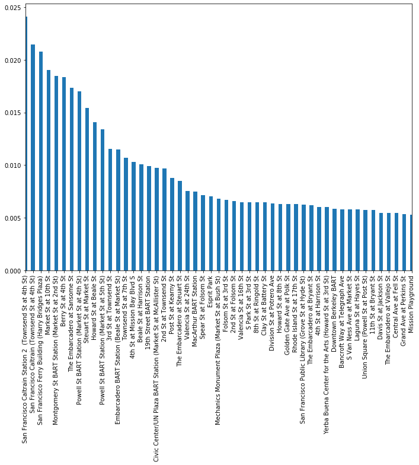

```python
plt.figure(figsize=[ 11.69, 8.27])
start = df2['start_station_name'].value_counts()
start.columns = ['name','freq']
end = df2['end_station_name'].value_counts()
most_used_stations =(start+end).sort_values(ascending =False)
(most_used_stations/most_used_stations.sum()).plot(kind='bar')
plt.xlim([0,50])
```

```python
(most_used_stations/most_used_stations.sum())[:54].sum()
```

```
0.5027524529007624
```

```python
(most_used_stations/most_used_stations.sum())[:50]
```

```
San Francisco Caltrain Station 2  (Townsend St at 4th St)          0.024105
San Francisco Caltrain (Townsend St at 4th St)                     0.021452
San Francisco Ferry Building (Harry Bridges Plaza)                 0.020753
Market St at 10th St                                               0.019005
Montgomery St BART Station (Market St at 2nd St)                   0.018477
Berry St at 4th St                                                 0.018349
The Embarcadero at Sansome St                                      0.017345
Powell St BART Station (Market St at 4th St)                       0.016992
Steuart St at Market St                                            0.015438
Howard St at Beale St                                              0.014070
Powell St BART Station (Market St at 5th St)                       0.013400
3rd St at Townsend St                                              0.011546
Embarcadero BART Station (Beale St at Market St)                   0.011503
Townsend St at 7th St                                              0.010672
4th St at Mission Bay Blvd S                                       0.010295
Beale St at Harrison St                                            0.010062
19th Street BART Station                                           0.009917
Civic Center/UN Plaza BART Station (Market St at McAllister St)    0.009720
2nd St at Townsend St                                              0.009668
Post St at Kearny St                                               0.008783
The Embarcadero at Steuart St                                      0.008484
Valencia St at 24th St                                             0.007552
MacArthur BART Station                                             0.007515
Spear St at Folsom St                                              0.007129
Esprit Park                                                        0.007038
Mechanics Monument Plaza (Market St at Bush St)                    0.006809
Folsom St at 3rd St                                                0.006695
2nd St at Folsom St                                                0.006613
Valencia St at 16th St                                             0.006488
S Park St at 3rd St                                                0.006480
8th St at Ringold St                                               0.006478
Clay St at Battery St                                              0.006458
Division St at Potrero Ave                                         0.006391
Howard St at 8th St                                                0.006312
Golden Gate Ave at Polk St                                         0.006301
Rhode Island St at 17th St                                         0.006296
San Francisco Public Library (Grove St at Hyde St)                 0.006277
The Embarcadero at Bryant St                                       0.006216
4th St at Harrison St                                              0.006055
Yerba Buena Center for the Arts (Howard St at 3rd St)              0.006005
Downtown Berkeley BART                                             0.005853
Bancroft Way at Telegraph Ave                                      0.005829
S Van Ness Ave at Market St                                        0.005807
Laguna St at Hayes St                                              0.005805
Union Square (Powell St at Post St)                                0.005765
11th St at Bryant St                                               0.005720
Davis St at Jackson St                                             0.005487
The Embarcadero at Vallejo St                                      0.005464
Central Ave at Fell St                                             0.005454
Grand Ave at Perkins St                                            0.005332
dtype: float64
```

> These station would need the maintenance alwayes plus it will show the pattern of the places the servies used Most and show gratitude for the users plus the top 50 station REPRESENT nearly 49% FROM the stations usage

# 2) Month Trends

### I'm looking for any abnormail activity throw the months during the 2018 year

```python
num_uses_per_month =df2['start_time'].groupby(df2.start_time.dt.month).agg('count')
num_uses_per_month
```

```
start_time
1      85754
2      97265
3     100943
4     120206
5     165573
6     179571
7     181875
8     176548
9     172934
10    189625
11    126921
12    124522
Name: start_time, dtype: int64
```

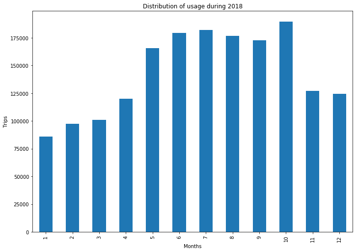

```python
plt.figure(figsize=[ 11.69, 8.27])

num_uses_per_month =df['start_time'].groupby(df.start_time.dt.month).agg('count')
num_uses_per_month
num_uses_per_month.plot(kind='bar');
plt.xlabel('Months');
plt.ylabel('Trips');
plt.title('Distribution of usage during 2018');
```

### it's show that the most used month releted to the summer and spring but also october was the busiest and that is strange I will need to look more deper it that month

## 3) age categories of users whom use the servies

## I did wanna know the age catagories for whom used the servies during 2018

```python
df.describe()
```

|  | duration_min | member_birth_year |
| --- | --- | --- |
| count | 1.721737e+06 | 1.721737e+06 |
| mean | 1.288241e+01 | 1.983140e+03 |
| std | 3.234613e+01 | 1.018201e+01 |
| min | 1.016667e+00 | 1.935000e+03 |
| 25% | 5.733333e+00 | 1.978000e+03 |
| 50% | 9.050000e+00 | 1.985000e+03 |
| 75% | 1.400000e+01 | 1.991000e+03 |
| max | 1.438017e+03 | 2.000000e+03 |

```python
df2.describe()##duration_min max value is outliers
```

|  | duration_min | member_birth_year |
| --- | --- | --- |
| count | 1.721737e+06 | 1.721737e+06 |
| mean | 1.288241e+01 | 3.586026e+01 |
| std | 3.234613e+01 | 1.018201e+01 |
| min | 1.016667e+00 | 1.900000e+01 |
| 25% | 5.733333e+00 | 2.800000e+01 |
| 50% | 9.050000e+00 | 3.400000e+01 |
| 75% | 1.400000e+01 | 4.100000e+01 |
| max | 1.438017e+03 | 8.400000e+01 |

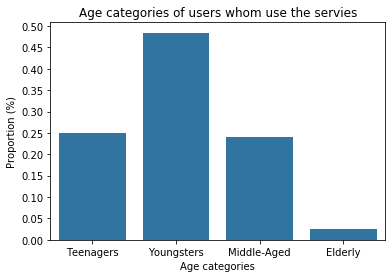

```python
bin_edge=[16,28,40,60,85]
bin_names=["Teenagers","Youngsters","Middle-Aged", "Elderly"]
df2['catagoial_age']=pd.cut(df2['member_birth_year'],bin_edge,labels=bin_names)

# get proportion taken by most common group for derivation
# of tick marks
n_points = df2.shape[0]
max_count = df2['catagoial_age'].value_counts().max()
max_prop = max_count / n_points

# generate tick mark locations and names
tick_props = np.arange(0, max_prop+.05, 0.05)
tick_names = ['{:0.2f}'.format(v) for v in tick_props]

# create the plot
base_color = sb.color_palette()[0]
sb.countplot(data = df2, x = 'catagoial_age', color = base_color);
plt.yticks(tick_props * n_points, tick_names);
plt.ylabel('Proportion (%)');
plt.xlabel('Age categories');
plt.title('Age categories of users whom use the servies');
```

# 4) gender spectram of users through 2018

## I did wanna know the gender spectram of users through2018

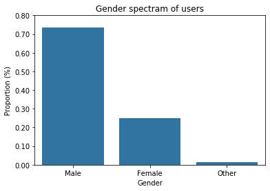

```python
_points = df2.shape[0]
max_count = df2['member_gender'].value_counts().max()
max_prop = max_count / n_points

tick_props = np.arange(0, max_prop+.1, 0.1)
tick_names = ['{:0.2f}'.format(v) for v in tick_props]

base_color = sb.color_palette()[0]
sb.countplot(data = df2, x = 'member_gender', color = base_color);
plt.yticks(tick_props * n_points, tick_names);

plt.ylabel('Proportion (%)');
plt.xlabel('Gender');
plt.title('Gender spectram of users');
```

```python
df2.member_gender.value_counts()/df2.shape[0]
```

```
Male      0.734817
Female    0.249891
Other     0.015293
Name: member_gender, dtype: float64
```

> this show that male users are 73% from user and see that might be wrong and right wrong as it might be the missing data in gender was female users and after droping the the male percentage incresd but I see right in anther way in which the men cloth are more suitable in riding bike then women

# Discuss the distribution(s) of your variable(s) of interest. Were there any unusual points? Did you need to perform any transformations?

> yes most of the ususual potins I have fix it during the wrangle process but still there duration problem which I didn't wanna work without it because it show that not few people forget to return the bike and return the next day or after the work and that causing a huge outliers

# Of the features you investigated, were there any unusual distributions? Did you perform any operations on the data to tidy, adjust, or change the form of the data? If so, why did you do this?

> yes I need to adjust and reform the data to be more easy to menuplate in the analysis

## Bivariate Exploration

```python
# makeing a new column have ride Month
df2['month']=df2.start_time.dt.month
## we would use this query inn analsis related to duration per min as it doesn't
#contain ahuge outlier and represent less than .05 from the data set
less120min=df2.query('duration_min <= 120 ')
```

```python
# making the month ordered catacogrial
df2.month=df2.month.astype(str)
level_order = ['1','2','3','4','5','6','7','8','9','10','11','12']
ordered_cat = pd.api.types.CategoricalDtype(ordered = True, categories = level_order)
df2['month'] = df2['month'].astype(ordered_cat)

df2
```

|  | duration_min | start_time | end_time | start_station_name | end_station_name | user_type | member_birth_year | member_gender | bike_share_for_all_trip | catagoial_age | month |
| --- | --- | --- | --- | --- | --- | --- | --- | --- | --- | --- | --- |
| 0 | 1254.733333 | 2018-01-31 22:52:35.239 | 2018-02-01 19:47:19.824 | Mission Dolores Park | Webster St at O'Farrell St | Subscriber | 33.0 | Male | No | Youngsters | 1 |
| 1 | 1192.933333 | 2018-01-31 14:23:55.889 | 2018-02-01 10:16:52.116 | Jackson St at 5th St | 5th St at Virginia St | Customer | 23.0 | Male | No | Teenagers | 1 |
| 2 | 666.100000 | 2018-01-31 19:52:24.667 | 2018-02-01 06:58:31.053 | Laguna St at Hayes St | Post St at Kearny St | Subscriber | 28.0 | Male | No | Teenagers | 1 |
| 3 | 7.550000 | 2018-01-31 23:53:53.632 | 2018-02-01 00:01:26.805 | 17th & Folsom Street Park (17th St at Folsom St) | Valencia St at 24th St | Subscriber | 31.0 | Male | No | Youngsters | 1 |
| 4 | 3.000000 | 2018-01-31 23:52:09.903 | 2018-01-31 23:55:10.807 | Berry St at 4th St | 4th St at Mission Bay Blvd S | Subscriber | 39.0 | Male | No | Youngsters | 1 |
| 5 | 16.600000 | 2018-01-31 23:34:56.004 | 2018-01-31 23:51:32.674 | Valencia St at 24th St | Cyril Magnin St at Ellis St | Subscriber | 32.0 | Male | Yes | Youngsters | 1 |
| 6 | 13.750000 | 2018-01-31 23:34:14.027 | 2018-01-31 23:47:59.809 | Ryland Park | San Salvador St at 9th St | Subscriber | 25.0 | Female | Yes | Teenagers | 1 |
| 7 | 7.200000 | 2018-01-31 23:34:26.484 | 2018-01-31 23:41:39.297 | Division St at Potrero Ave | San Francisco Public Library (Grove St at Hyde... | Subscriber | 26.0 | Male | No | Teenagers | 1 |
| 8 | 10.016667 | 2018-01-31 23:29:46.832 | 2018-01-31 23:39:48.000 | 16th St Mission BART Station 2 | Market St at Dolores St | Subscriber | 62.0 | Male | No | Elderly | 1 |
| 9 | 14.783333 | 2018-01-31 23:24:16.357 | 2018-01-31 23:39:04.123 | San Pedro Square | Locust St at Grant St | Subscriber | 43.0 | Female | Yes | Middle-Aged | 1 |
| 10 | 3.500000 | 2018-01-31 23:33:03.046 | 2018-01-31 23:36:33.704 | Frank H Ogawa Plaza | Lakeside Dr at 14th St | Subscriber | 43.0 | Male | No | Middle-Aged | 1 |
| 11 | 3.133333 | 2018-01-31 23:30:58.136 | 2018-01-31 23:34:06.391 | Valencia St at 16th St | McCoppin St at Valencia St | Subscriber | 55.0 | Female | No | Middle-Aged | 1 |
| 12 | 13.466667 | 2018-01-31 23:19:58.603 | 2018-01-31 23:33:27.531 | San Francisco Caltrain Station 2 (Townsend St... | Valencia St at 16th St | Subscriber | 43.0 | Male | Yes | Middle-Aged | 1 |
| 13 | 6.300000 | 2018-01-31 23:23:23.068 | 2018-01-31 23:29:42.044 | Townsend St at 5th St | Folsom St at 9th St | Subscriber | 24.0 | Female | No | Teenagers | 1 |
| 14 | 11.433333 | 2018-01-31 23:07:15.313 | 2018-01-31 23:18:41.558 | San Jose Diridon Station | San Salvador St at 9th St | Subscriber | 22.0 | Female | No | Teenagers | 1 |
| 15 | 7.500000 | 2018-01-31 23:07:13.063 | 2018-01-31 23:14:43.814 | Ashby BART Station | 65th St at Hollis St | Subscriber | 25.0 | Male | No | Teenagers | 1 |
| 16 | 4.900000 | 2018-01-31 23:08:12.000 | 2018-01-31 23:13:06.636 | Bancroft Way at Telegraph Ave | Shattuck Ave at Hearst Ave | Subscriber | 36.0 | Male | No | Youngsters | 1 |
| 17 | 2.500000 | 2018-01-31 23:10:09.586 | 2018-01-31 23:12:40.333 | 19th Street BART Station | Telegraph Ave at 19th St | Subscriber | 74.0 | Male | Yes | Elderly | 1 |
| 18 | 7.700000 | 2018-01-31 23:03:48.940 | 2018-01-31 23:11:31.029 | 18th St at Noe St | Valencia St at 24th St | Subscriber | 48.0 | Male | Yes | Middle-Aged | 1 |
| 19 | 6.316667 | 2018-01-31 23:04:27.701 | 2018-01-31 23:10:46.976 | MacArthur BART Station | Genoa St at 55th St | Subscriber | 44.0 | Male | No | Middle-Aged | 1 |
| 20 | 14.666667 | 2018-01-31 22:53:41.302 | 2018-01-31 23:08:21.443 | Folsom St at 19th St | 29th St at Church St | Subscriber | 33.0 | Male | No | Youngsters | 1 |
| 21 | 20.166667 | 2018-01-31 22:45:37.125 | 2018-01-31 23:05:47.576 | Webster St at O'Farrell St | Valencia St at 22nd St | Subscriber | 28.0 | Male | No | Teenagers | 1 |
| 22 | 4.316667 | 2018-01-31 23:01:12.792 | 2018-01-31 23:05:32.157 | Bancroft Way at Telegraph Ave | Parker St at Fulton St | Subscriber | 25.0 | Male | No | Teenagers | 1 |
| 23 | 9.866667 | 2018-01-31 22:53:27.779 | 2018-01-31 23:03:20.290 | Washington St at 8th St | Bay Pl at Vernon St | Customer | 41.0 | Male | No | Middle-Aged | 1 |
| 24 | 17.650000 | 2018-01-31 22:45:16.570 | 2018-01-31 23:02:56.285 | Valencia St at Cesar Chavez St | 7th St at Brannan St | Subscriber | 31.0 | Male | No | Youngsters | 1 |
| 25 | 6.250000 | 2018-01-31 22:56:31.082 | 2018-01-31 23:02:46.583 | San Francisco Ferry Building (Harry Bridges Pl... | The Embarcadero at Sansome St | Subscriber | 31.0 | Male | No | Youngsters | 1 |
| 26 | 5.000000 | 2018-01-31 22:57:24.042 | 2018-01-31 23:02:24.272 | Rhode Island St at 17th St | 4th St at Mission Bay Blvd S | Subscriber | 38.0 | Male | No | Youngsters | 1 |
| 27 | 36.983333 | 2018-01-31 22:24:39.943 | 2018-01-31 23:01:39.571 | San Francisco Caltrain (Townsend St at 4th St) | Berry St at 4th St | Subscriber | 28.0 | Female | No | Teenagers | 1 |
| 28 | 5.500000 | 2018-01-31 22:55:48.073 | 2018-01-31 23:01:18.506 | Folsom St at 15th St | 19th St at Florida St | Subscriber | 36.0 | Male | No | Youngsters | 1 |
| 29 | 14.500000 | 2018-01-31 22:45:38.235 | 2018-01-31 23:00:09.034 | Webster St at O'Farrell St | Sanchez St at 17th St | Customer | 29.0 | Female | No | Youngsters | 1 |
| ... | ... | ... | ... | ... | ... | ... | ... | ... | ... | ... | ... |
| 1721707 | 3.033333 | 2018-12-01 00:52:29.077 | 2018-12-01 00:55:32.066 | Montgomery St BART Station (Market St at 2nd St) | Howard St at Beale St | Subscriber | 24.0 | Male | No | Teenagers | 12 |
| 1721708 | 5.533333 | 2018-12-01 00:48:31.323 | 2018-12-01 00:54:04.239 | Central Ave at Fell St | Scott St at Golden Gate Ave | Subscriber | 25.0 | Male | No | Teenagers | 12 |
| 1721709 | 5.516667 | 2018-12-01 00:48:27.529 | 2018-12-01 00:53:59.495 | Central Ave at Fell St | Scott St at Golden Gate Ave | Subscriber | 25.0 | Male | No | Teenagers | 12 |
| 1721710 | 5.166667 | 2018-12-01 00:45:44.868 | 2018-12-01 00:50:55.797 | Channing Way at Shattuck Ave | MLK Jr Way at University Ave | Subscriber | 28.0 | Male | No | Teenagers | 12 |
| 1721711 | 22.300000 | 2018-12-01 00:27:24.875 | 2018-12-01 00:49:43.349 | Lombard St at Columbus Ave | 4th St at 16th St | Subscriber | 33.0 | Male | No | Youngsters | 12 |
| 1721712 | 2.566667 | 2018-12-01 00:44:24.838 | 2018-12-01 00:46:59.335 | Central Ave at Fell St | McAllister St at Baker St | Subscriber | 25.0 | Male | No | Teenagers | 12 |
| 1721713 | 14.366667 | 2018-12-01 00:32:11.063 | 2018-12-01 00:46:33.790 | Cyril Magnin St at Ellis St | Market St at Dolores St | Customer | 44.0 | Male | No | Middle-Aged | 12 |
| 1721714 | 21.833333 | 2018-12-01 00:23:53.342 | 2018-12-01 00:45:43.588 | Church St at Duboce Ave | Commercial St at Montgomery St | Subscriber | 25.0 | Male | Yes | Teenagers | 12 |
| 1721715 | 3.833333 | 2018-12-01 00:41:31.955 | 2018-12-01 00:45:22.416 | San Jose Diridon Station | Santa Clara St at Almaden Blvd | Subscriber | 62.0 | Male | No | Elderly | 12 |
| 1721716 | 34.516667 | 2018-12-01 00:09:55.580 | 2018-12-01 00:44:26.629 | Folsom St at 3rd St | 14th St at Mission St | Customer | 28.0 | Male | No | Teenagers | 12 |
| 1721717 | 32.633333 | 2018-12-01 00:11:35.022 | 2018-12-01 00:44:13.632 | Civic Center/UN Plaza BART Station (Market St ... | Powell St BART Station (Market St at 5th St) | Subscriber | 26.0 | Male | No | Teenagers | 12 |
| 1721718 | 4.466667 | 2018-12-01 00:37:23.134 | 2018-12-01 00:41:51.967 | 29th St at Tiffany Ave | Mission Playground | Subscriber | 30.0 | Male | No | Youngsters | 12 |
| 1721719 | 27.983333 | 2018-12-01 00:13:35.143 | 2018-12-01 00:41:34.860 | Haste St at Telegraph Ave | Downtown Berkeley BART | Customer | 21.0 | Female | No | Teenagers | 12 |
| 1721720 | 27.633333 | 2018-12-01 00:13:33.124 | 2018-12-01 00:41:11.763 | Haste St at Telegraph Ave | Downtown Berkeley BART | Customer | 21.0 | Female | No | Teenagers | 12 |
| 1721721 | 4.883333 | 2018-12-01 00:36:01.525 | 2018-12-01 00:40:55.285 | Sanchez St at 15th St | Page St at Scott St | Subscriber | 38.0 | Male | No | Youngsters | 12 |
| 1721722 | 7.100000 | 2018-12-01 00:32:13.125 | 2018-12-01 00:39:19.871 | 2nd St at Townsend St | Montgomery St BART Station (Market St at 2nd St) | Subscriber | 33.0 | Male | No | Youngsters | 12 |
| 1721723 | 7.450000 | 2018-12-01 00:31:36.148 | 2018-12-01 00:39:03.391 | Myrtle St at Polk St | Embarcadero BART Station (Beale St at Market St) | Subscriber | 39.0 | Other | Yes | Youngsters | 12 |
| 1721724 | 28.233333 | 2018-12-01 00:09:17.159 | 2018-12-01 00:37:31.240 | Clay St at Battery St | 29th St at Tiffany Ave | Subscriber | 26.0 | Male | No | Teenagers | 12 |
| 1721725 | 4.483333 | 2018-12-01 00:31:00.091 | 2018-12-01 00:35:29.871 | Valencia St at 16th St | Mission Playground | Subscriber | 26.0 | Male | No | Teenagers | 12 |
| 1721726 | 11.416667 | 2018-12-01 00:21:16.240 | 2018-12-01 00:32:42.000 | 17th St at Valencia St | 8th St at Ringold St | Subscriber | 32.0 | Female | No | Youngsters | 12 |
| 1721727 | 11.350000 | 2018-12-01 00:19:41.383 | 2018-12-01 00:31:02.605 | San Francisco Ferry Building (Harry Bridges Pl... | Broadway at Kearny | Subscriber | 60.0 | Male | No | Middle-Aged | 12 |
| 1721728 | 12.716667 | 2018-12-01 00:17:34.497 | 2018-12-01 00:30:18.107 | Pierce St at Haight St | Mission Playground | Subscriber | 28.0 | Female | No | Teenagers | 12 |
| 1721729 | 12.666667 | 2018-12-01 00:17:29.960 | 2018-12-01 00:30:10.178 | Pierce St at Haight St | Mission Playground | Subscriber | 28.0 | Male | No | Teenagers | 12 |
| 1721730 | 8.966667 | 2018-12-01 00:16:34.085 | 2018-12-01 00:25:32.455 | Powell St BART Station (Market St at 5th St) | Scott St at Golden Gate Ave | Subscriber | 28.0 | Male | No | Teenagers | 12 |
| 1721731 | 11.183333 | 2018-12-01 00:12:49.640 | 2018-12-01 00:24:01.512 | Father Alfred E Boeddeker Park | Mission Bay Kids Park | Subscriber | 47.0 | Male | Yes | Middle-Aged | 12 |
| 1721732 | 8.300000 | 2018-12-01 00:14:41.725 | 2018-12-01 00:23:00.408 | Frank H Ogawa Plaza | Market St at Brockhurst St | Subscriber | 27.0 | Male | No | Teenagers | 12 |
| 1721733 | 18.950000 | 2018-12-01 00:01:49.693 | 2018-12-01 00:20:47.519 | Pierce St at Haight St | 2nd St at Townsend St | Subscriber | 29.0 | Male | No | Youngsters | 12 |
| 1721734 | 7.883333 | 2018-12-01 00:11:54.811 | 2018-12-01 00:19:48.547 | Hubbell St at 16th St | Berry St at 4th St | Subscriber | 37.0 | Female | No | Youngsters | 12 |
| 1721735 | 14.016667 | 2018-12-01 00:02:48.726 | 2018-12-01 00:16:49.766 | Washington St at Kearny St | Market St at 10th St | Subscriber | 20.0 | Female | No | Teenagers | 12 |
| 1721736 | 4.866667 | 2018-12-01 00:03:06.549 | 2018-12-01 00:07:59.080 | 4th St at Mission Bay Blvd S | Esprit Park | Subscriber | 56.0 | Male | No | Middle-Aged | 12 |

1721737 rows × 11 columns

```python
df2.info()
```

```
<class 'pandas.core.frame.DataFrame'>
RangeIndex: 1721737 entries, 0 to 1721736
Data columns (total 11 columns):
duration_min               float64
start_time                 datetime64[ns]
end_time                   datetime64[ns]
start_station_name         object
end_station_name           object
user_type                  object
member_birth_year          float64
member_gender              object
bike_share_for_all_trip    object
catagoial_age              category
month                      category
dtypes: category(2), datetime64[ns](2), float64(2), object(5)
memory usage: 121.5+ MB
```

```python
avg_ride_per_month=less120min['duration_min'].groupby(df.start_time.dt.month).mean()
avg_ride_per_month
```

```
start_time
1     10.832679
2     10.945665
3     10.819953
4     11.063692
5     11.270786
6     11.607072
7     11.811194
8     11.490143
9     11.859318
10    11.354022
11    10.945687
12    11.286929
Name: duration_min, dtype: float64
```

## Relation between the average bike ride in every month

> what's the average bike ride during 2018 ?

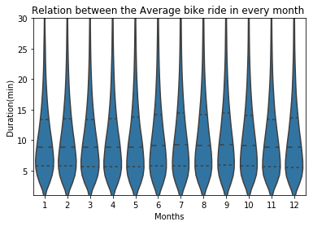

```python
base_color = sb.color_palette()[0]
sb.violinplot(data = less120min,x ='month', y ='duration_min',color=base_color,inner='quartile');
plt.ylim([1,30]);
plt.ylabel('Duration(min)');
plt.xlabel('Months');
plt.title('Relation between the Average bike ride in every month ');
```

> it's around 9 min

## Relation between the average user's age in every month

> what is age of new users ?

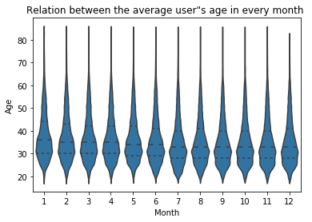

```python
base_color = sb.color_palette()[0]
sb.violinplot(data = df2,x ='month', y ='member_birth_year',inner='quartile',color=base_color);
plt.ylabel('Age');
plt.xlabel('Month');
plt.title('Relation between the average user"s age in every month ');
```

> it show some decreasing trend in the age by more time the servies is opreating

# Gender and User type relation

> what Gender are more attracct to our servise?

```python
total_men=df2.query(' member_gender == "Male" ')
total_women=df2.query('member_gender == "Female"' )
total_other=df2.query('member_gender == "Other"')
total_men_Subscriber=total_men.query('user_type == "Subscriber"').count()[0]
total_men_customer=total_men.count()[0]-total_men_Subscriber
total_women_Subscriber=total_women.query('user_type == "Subscriber"').count()[0]
total_women_customer=total_women.count()[0]-total_women_Subscriber
```

```python
total_women_customer
```

```
62538
```

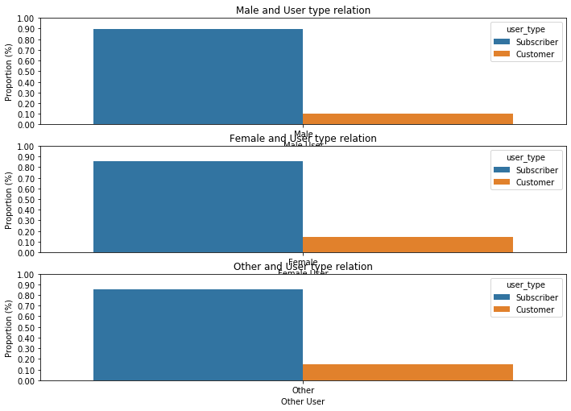

```python
#Men
plt.figure(figsize=[ 11.69, 8.27])
plt.subplot(3, 1, 1)
n_points = total_men.shape[0]
max_count = total_men['member_gender'].value_counts().max()
max_prop = max_count / n_points
tick_props = np.arange(0, max_prop+.1, 0.1)
tick_names = ['{:0.2f}'.format(v) for v in tick_props]
sb.countplot(data= total_men,x='member_gender',hue='user_type');
plt.yticks(tick_props * n_points, tick_names);
plt.ylabel('Proportion (%)');
plt.xlabel('Male User');
plt.title('Male and User type relation');
#Woman
plt.subplot(3, 1, 2)
n_points = total_women.shape[0]
max_count = total_women['member_gender'].value_counts().max()
max_prop = max_count / n_points
tick_props = np.arange(0, max_prop+.1, 0.1)
tick_names = ['{:0.2f}'.format(v) for v in tick_props]
sb.countplot(data= total_women,x='member_gender',hue='user_type');
plt.yticks(tick_props * n_points, tick_names);
plt.ylabel('Proportion (%)');
plt.xlabel('Female User');
plt.title('Female and User type relation');
#Other
plt.subplot(3, 1, 3)
n_points = total_other.shape[0]
max_count = total_other['member_gender'].value_counts().max()
max_prop = max_count / n_points
tick_props = np.arange(0, max_prop+.1, 0.1)
tick_names = ['{:0.2f}'.format(v) for v in tick_props]
sb.countplot(data= total_other,x='member_gender',hue='user_type');
plt.yticks(tick_props * n_points, tick_names);
plt.ylabel('Proportion (%)');
plt.xlabel('Other User');
plt.title('Other and User type relation');
```

### Talk about some of the relationships you observed in this part of the investigation. How did the feature(s) of interest vary with other features in the dataset?

> 1) Relation between the average user's age in every month )

> As Visualization shows that Average user age have decresing trend and that might illastreat that the servies start to get more popular between the younger than average so I recomend to to start awarnes campaign within younger as the represent a huge markert share with our servies

> 2) ( Gender and User type relation ) As Visualization shows that the subscribers percentage on average ranges between (85~89%) dispite the gender and the diffrance between the gender isn't significant

### Did you observe any interesting relationships between the other features (not the main feature(s) of interest)?

> Month rides vs the user Type doesn't have Obvious pattern would need more study

## ( Releationships between Member gender, monthe and Membership Type )

> I did wanna scan for pattern in this relation

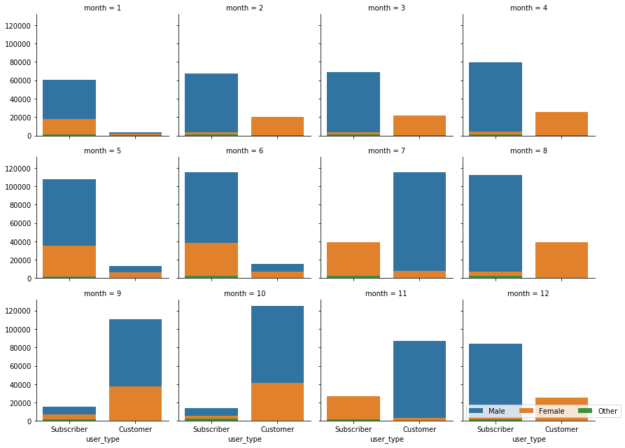

```python
g = sb.FacetGrid(data = df2, col = 'month',hue='member_gender',col_wrap=4);
g.map(sb.countplot,'user_type');
plt.legend(loc = 3, ncol = 3);
```

### in ( Releationships between Member gender,monthe and Membership Type )

# Releationship between Member gender,Member age and Membership Type

> I want to know results in this relation

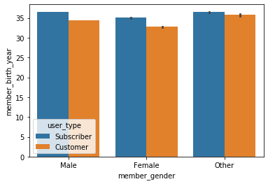

```python
sb.barplot(data = df2, x = 'member_gender', y = 'member_birth_year', hue = 'user_type')
```

### In this Releationship between Member gender,Member age and Membership Type

> Here it show that the average age to female/subscriber is nearly 35 year and female/customer is nerly 32 year

> Here it show that the average age to Other/subscriber is nearly 37 year and male/customer is nerly 35 year

## Releationship between Member gender,Duration (min) and Membership Type

> I did wanna to know results in this relation

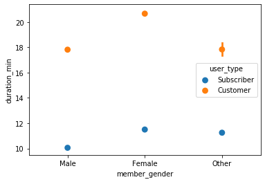

```python
ax = sb.pointplot(data = less120min, x = 'member_gender', y = 'duration_min', hue = 'user_type', linestyles = "")
```

### Releationship between Member gender,Duration (min) and Membership Type

> Here it show that the average Ride Duration(min) to male/subscriber is nearly 10min and male/customer is nerly 18min

> Here it show that the average Ride Duration(min) to Other/subscriber is nearly 11min and male/customer is nerly 17min

> and here it show that the average ride for female user is longest than the other  
> and also show that the duration average nerly double in case of customer membership despite the Gender

### Talk about some of the relationships you observed in this part of the investigation. Were there features that strengthened each other in terms of looking at your feature(s) of interest?

> for sure this investigation was able to shhow some pattern and information about the user and serives that I hope to be useful for any team would work on it and for the second question I see that doing Multivariate Exploration helped in show more in depth what happen some monthes

### Were there any interesting or surprising interactions between features?

> I would say yes for this relation Member gender,month and Membership Type it did show some show some serprisong insights

```python
df2.to_csv('Ford_GoBike_System_Data_2018_wrangled.csv', index = None, header=True)
```

```python
df2.info()
```

```
<class 'pandas.core.frame.DataFrame'>
RangeIndex: 1721737 entries, 0 to 1721736
Data columns (total 11 columns):
duration_min               float64
start_time                 datetime64[ns]
end_time                   datetime64[ns]
start_station_name         object
end_station_name           object
user_type                  object
member_birth_year          float64
member_gender              object
bike_share_for_all_trip    object
catagoial_age              category
month                      category
dtypes: category(2), datetime64[ns](2), float64(2), object(5)
memory usage: 121.5+ MB
```